# Random Forest Parameter Tuning

Chamroeun Chhay

7 September 2021

Lets first load a few packages which we will use for this analysis:

```r
#install.packages("randomForest")
#install.packages("caret")
library(randomForest)
library(caret)
library(xgboost)
library(pROC)
```

## Random Forests

The random forest algorithm works by building bootstrapped trees using only a selection of variables to split the data at each node.

The tuning parameters we can use for random forests are:

- Number of trees - The number of trees we build in the model
- mtry - The number of variables tried at each split in the model
- nodesize - The minimum size of the terminal nodes (Default 5)

Some other parameters that can affect the model are:

- sampsize - The sizes of the bootstrap sample to take (Can be used for imbalanced data by specifying the number of samples from each class to use.)
- maxnodes - The maximum number of terminal nodes in the model (This is generally controlled for using the nodesize parameter)
- replace - Should the sampled datasets used for each tree be taken with replacement for the data.(Answer for this is yes unless only using a subsample of the data)

In general random forests will not overfit our data. Therefore we can build a large number of trees and focus on tuning the mtry and node size parameters. Which will allow us to visualize the parameter combinations and how they perform.

## TOR Data

For this analysis we are going to be analyzing internet connections to predict if they come from the dark web.

Darknet is the unused address space of the internet which is not speculated to interact with other computers in the world. Any communication from the dark space is considered skeptical owing to its passive listening nature which accepts incoming packets, but outgoing packets are not supported. Due to the absence of legitimate hosts in the darknet, any traffic is contemplated to be unsought and is characteristically treated as probe, backscatter, or misconfiguration. Darknets are also known as network telescopes, sinkholes, or blackholes.

To access the Darknet or Darkweb people will generally use the TOR browser:

“Back in the mid-’90s, when the US Navy was looking into ways to securely communicate sensitive intelligence information, a mathematician and two computer scientists emerged from the Naval Research Lab with something called”onion routing.” It was a new kind of technology that would protect your internet traffic with layers of privacy. By 2003, The Onion Routing project, acronymed Tor, was in the hands of the public, where its vast network of users – the engine enabling Tor – has since continued to grow.

Today, thousands of volunteers all over the world are connecting their computers to the internet to create the Tor network by becoming “nodes” or “relays” for your internet traffic.

At a basic level, Tor is a type of internet-connected network with its own internet browser. Once you connect to the internet with the Tor browser, your internet traffic is stripped of its first layer of identifying information as it enters the Tor network, and is then sent bouncing through those relay nodes, which serve to encrypt and privatize your data, layer by layer – like an onion. Finally, your traffic hits an exit node and leaves the Tor network for the open web.

Once you’re in the Tor network, it’s nearly impossible for others to track your traffic’s manic pinballing path across the globe. And once you leave the Tor network via an exit node, the website you view (assuming it has HTTPS in front of its address) isn’t sure which part of the world you’re hailing from, offering you more privacy and protection.”

This data is stored as `tor_data.rda`. Lets load the data into the work space:

```r
load("tor_data.rda")
```

The data is already split into training and test sets using an 80/20 split called `train_db` and `test_db` respectively.

```r
summary(train_db)
```

```
##  Flow.Duration      Flow.Bytes.s       Flow.Packets.s      Flow.IAT.Mean
##  Min.   :      1   Min.   :        0   Min.   :      0.2   Min.   :      0
##  1st Qu.:  44305   1st Qu.:      105   1st Qu.:      4.9   1st Qu.:   9950
##  Median : 410823   Median :     1330   Median :     16.3   Median :  83224
##  Mean   :2974680   Mean   :   264002   Mean   :   3367.5   Mean   : 314766
##  3rd Qu.:7214797   3rd Qu.:    21907   3rd Qu.:    100.7   3rd Qu.: 410591
##  Max.   :9999999   Max.   :600000000   Max.   :3000000.0   Max.   :9987113
##   Flow.IAT.Std      Flow.IAT.Max      Flow.IAT.Min      Fwd.IAT.Mean
##  Min.   :      0   Min.   :      1   Min.   :  -2255   Min.   :      0
##  1st Qu.:      0   1st Qu.:  29453   1st Qu.:     26   1st Qu.:      0
##  Median :      0   Median : 179044   Median :   1389   Median :  19967
##  Mean   : 218993   Mean   : 892583   Mean   : 192835   Mean   : 348509
##  3rd Qu.:  56949   3rd Qu.: 452397   3rd Qu.: 207957   3rd Qu.: 411216
##  Max.   :7045167   Max.   :9996903   Max.   :9987113   Max.   :9997140
##   Fwd.IAT.Std       Fwd.IAT.Max       Fwd.IAT.Min       Bwd.IAT.Mean
##  Min.   :      0   Min.   :      0   Min.   :   -186   Min.   :      0
##  1st Qu.:      0   1st Qu.:      0   1st Qu.:      0   1st Qu.:      0
##  Median :      0   Median :  99606   Median :     33   Median :      0
##  Mean   : 228953   Mean   : 864449   Mean   : 209967   Mean   : 118713
##  3rd Qu.:  29856   3rd Qu.: 436445   3rd Qu.: 203846   3rd Qu.:  17555
##  Max.   :7065086   Max.   :9997140   Max.   :9997140   Max.   :9996903
##   Bwd.IAT.Std       Bwd.IAT.Max       Bwd.IAT.Min       Active.Mean
##  Min.   :      0   Min.   :      0   Min.   :   -292   Min.   :      0
##  1st Qu.:      0   1st Qu.:      0   1st Qu.:      0   1st Qu.:      0
##  Median :      0   Median :      0   Median :      0   Median :      0
##  Mean   : 118708   Mean   : 472191   Mean   :  50658   Mean   :  38598
##  3rd Qu.:   9419   3rd Qu.:  82438   3rd Qu.:     17   3rd Qu.:      0
##  Max.   :7053719   Max.   :9996903   Max.   :9996903   Max.   :4999863
##    Active.Std   Active.Max        Active.Min        Idle.Mean          Idle.Std
##  Min.   :0    Min.   :      0   Min.   :      0   Min.   :      0   Min.   :0
##  1st Qu.:0    1st Qu.:      0   1st Qu.:      0   1st Qu.:      0   1st Qu.:0
##  Median :0    Median :      0   Median :      0   Median :      0   Median :0
##  Mean   :0    Mean   :  38598   Mean   :  38598   Mean   : 304459   Mean   :0
##  3rd Qu.:0    3rd Qu.:      0   3rd Qu.:      0   3rd Qu.:      0   3rd Qu.:0
##  Max.   :0    Max.   :4999863   Max.   :4999863   Max.   :9996903   Max.   :0
##     Idle.Max          Idle.Min          label
##  Min.   :      0   Min.   :      0   nonTOR:47828
##  1st Qu.:      0   1st Qu.:      0   TOR   : 6436
##  Median :      0   Median :      0
##  Mean   : 304459   Mean   : 304459
##  3rd Qu.:      0   3rd Qu.:      0
##  Max.   :9996903   Max.   :9996903
```

We see we have 24 variables for our analysis. These variables relate to the network connection made between the source and destination. The way internet traffic works is that data is broken up into packets and sent from the source to the destination which then sends packets back to the source. A flow becomes inactive after no packets have been observed for a period of time, this value is usually 15 seconds. The variables we have are:

- Flow.Duration - A flow refers to any connection or connection-like communication channel. The duration measures the length of time between the first and last packets sent.
- Flow.Bytes.s - Number of bytes sent in the connection
- Flow.Packets.s - Number of packets sent in the communication
- Flow.IAT.Mean - Packets flow inter arrival time Mean
- Flow.IAT.Std - Packets flow inter arrival time Standard deviation
- Flow.IAT.Max - Packets flow inter arrival time Max.
- Flow.IAT.Min - Packets flow inter arrival time Min
- Fwd.IAT.Mean - Forward inter arrival time, the time between two packets Sent forward direction Mean
- Fwd.IAT.Std - Forward inter arrival time, the time between two packets sent forward direction Standard deviation.
- Fwd.IAT.Max - Forward inter arrival time, the time between two packets sent forward direction Max
- Fwd.IAT.Min - Forward inter arrival time, the time between two packets sent forward direction Min.
- Bwd.IAT.Mean -Backward inter arrival time, the time between two packets sent backward Mean.
- Bwd.IAT.Std - Backward inter arrival time, the time between two packets sent backward Standard deviation.
- Bwd.IAT.Max - Backward inter arrival time, the time between two packets sent backward Max.
- Bwd.IAT.Min - Backward inter arrival time, the time between two packets sent backward Min
- Active.Mean - The amount of time a flow was active before becoming idle mean.
- Active.Std - The amount of time a flow was active before becoming idle Standard deviation
- Active.Max - The amount of time a flow was active before becoming idle Max.
- Active.Min - The amount of time a flow was active before becoming idle Min.
- Idle.Mean - The amount of time a flow was idle before becoming active Mean
- Idle.Std - The amount of time a flow was idle before becoming active Std deviation.
- Idle.Max - The amount of time a flow was idle before becoming active Max.
- Idle.Min - The amount of time a flow was idle before becoming active Min.
- label - Either TOR indicating a TOR connection or nonTOR indication a non-TOR connection

We will use the label as a response variable and the other variables as explanatory variables.

# Best Random Forest

```r
rf_mod <- randomForest(label ~., # Set tree formula
                         data = train_db, # Set dataset
                         ntree = 200,
                         nodesize = 1,
                         mtry = 12) # Set number of trees to use
rf_preds <- predict(rf_mod, test_db, type = "prob") # Create predictions for random forest model

# Convert predictions to classes, using 0.5
rf_pred_class <- rep("nonTOR", nrow(rf_preds))
rf_pred_class[rf_preds[,2] >= 0.5] <- "TOR"

t <- table(rf_pred_class, test_db$label) # Create table
confusionMatrix(t, positive = "TOR") # Produce confusion matrix
```

```
## Confusion Matrix and Statistics
##
##
## rf_pred_class nonTOR   TOR
##        nonTOR  11895    86
##        TOR        61  1522
##
##                Accuracy : 0.9892
##                  95% CI : (0.9873, 0.9908)
##     No Information Rate : 0.8815
##     P-Value [Acc > NIR] : < 2e-16
##
##                   Kappa : 0.9478
##
##  Mcnemar's Test P-Value : 0.04776
##
##             Sensitivity : 0.9465
##             Specificity : 0.9949
##          Pos Pred Value : 0.9615
##          Neg Pred Value : 0.9928
##              Prevalence : 0.1185
##          Detection Rate : 0.1122
##    Detection Prevalence : 0.1167
##       Balanced Accuracy : 0.9707
##
##        'Positive' Class : TOR
##
```

## Assignment - 20 Total Marks

- Apply a bagging model to the DarkNet dataset (2 marks)

```r
set.seed(258506)

# Use random forest to do bagging
bag_mod <- randomForest(label ~.,
                data = train_db,
                mtry = 24,
                ntree = 200)
bag_mod
```

```
##
## Call:
##  randomForest(formula = label ~ ., data = train_db, mtry = 24,      ntree = 200)
##                Type of random forest: classification
##                      Number of trees: 200
## No. of variables tried at each split: 23
##
##         OOB estimate of  error rate: 1.14%
## Confusion matrix:
##        nonTOR  TOR class.error
## nonTOR  47542  286 0.005979761
## TOR       334 6102 0.051895587
```

```r
bag_preds <- predict(bag_mod, test_db, type ="prob")
```

- Apply an XGBoost model to the DarkNet dataset (2 marks)

```r
dtrain <- xgb.DMatrix(data = as.matrix(train_db[, 1:23]), label = as.numeric(train_db$label) -1)
# Create test matrix
dtest <- xgb.DMatrix(data = as.matrix(test_db[, 1:23]), label = as.numeric(test_db$label) - 1)
```

```r
set.seed(1123111)
bst_1 <- xgboost(data = dtrain,
               nrounds = 100,
               verbose = 1,
                print_every_n = 20,
               objective = "binary:logistic",
               eval_metric = "auc",
               eval_metric = "error")
```

- Visualize and decide the optimal number of iterations for XGBoost.(Plot the error curve against the number of iterations) (2 marks)

```r
bst <- xgb.cv(data = dtrain,
              nfold = 5,
               nrounds = 250,
               early_stopping_rounds = 50,
               verbose = 1,
               nthread = 1,
               print_every_n = 20,
               objective = "binary:logistic", # Set objective
               eval_metric = "auc",
               eval_metric = "error")
```

```
## Multiple eval metrics are present. Will use test_error for early stopping.
## Will train until test_error hasn't improved in 50 rounds.
##
```

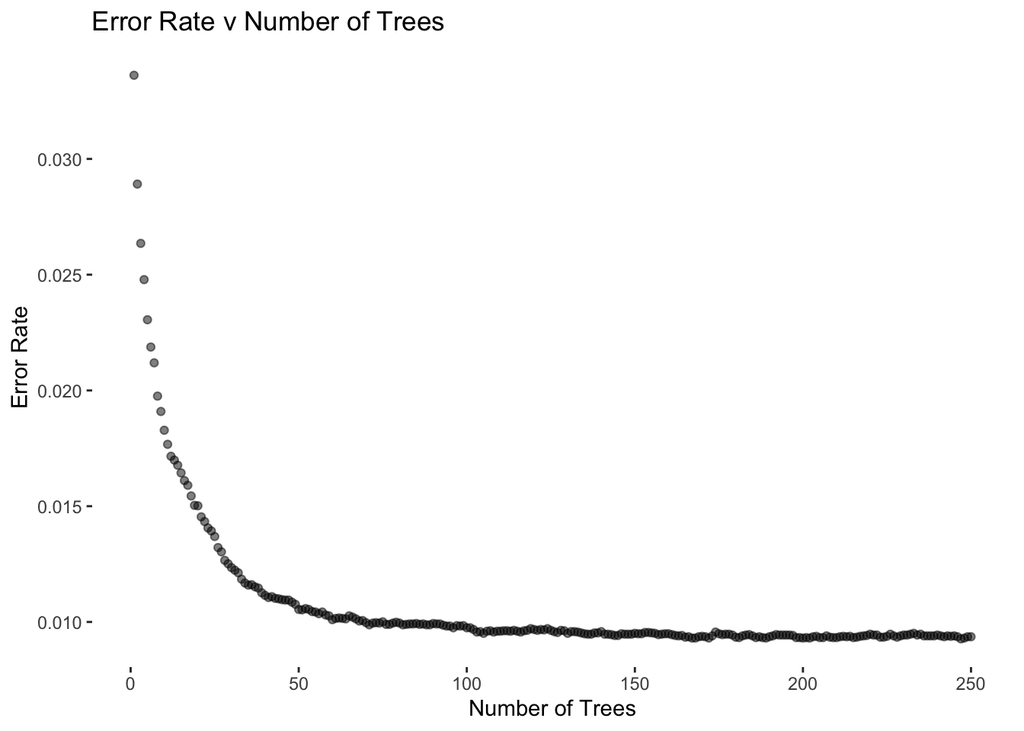

```r
g_6 <- ggplot(bst$evaluation_log, aes(x = iter, y = test_error_mean))+
  geom_point(alpha = 0.5) +
  theme_bw() +
  theme(panel.grid.major = element_blank(),
        panel.grid.minor = element_blank(),
        panel.border = element_blank(),
        panel.background = element_blank()) +
  labs(x = "Number of Trees", title = "Error Rate v Number of Trees",
       y = "Error Rate", color = "Learning \n Rate")
g_6
```

- Tune the eta parameter for XGboost (2 marks)

```r
set.seed(121111)
bst_mod_1 <-  xgb.cv(data = dtrain,
              nfold = 5,
              eta = 0.3,
              nrounds = 250,
              early_stopping_rounds = 50,
               verbose = 1,
               nthread = 1,
               print_every_n = 20,
               objective = "binary:logistic",
               eval_metric = "auc",
               eval_metric = "error")
```

```
## Multiple eval metrics are present. Will use test_error for early stopping.
## Will train until test_error hasn't improved in 50 rounds.
##
```

```r
set.seed(121111)
bst_mod_2 <-  xgb.cv(data = dtrain,
              nfold = 5,
              eta = 0.1,
              nrounds = 250,
              early_stopping_rounds = 50,
               verbose = 1,
               nthread = 1,
               print_every_n = 20,
               objective = "binary:logistic",
               eval_metric = "auc",
               eval_metric = "error")
```

```
## Multiple eval metrics are present. Will use test_error for early stopping.
## Will train until test_error hasn't improved in 50 rounds.
##
```

```r
set.seed(121111)
bst_mod_3 <- xgb.cv(data = dtrain,
              nfold = 5,
              eta = 0.05,
              nrounds = 250,
              early_stopping_rounds = 50,
               verbose = 1,
               nthread = 1,
               print_every_n = 20,
               objective = "binary:logistic",
               eval_metric = "auc",
               eval_metric = "error")
```

```
## Multiple eval metrics are present. Will use test_error for early stopping.
## Will train until test_error hasn't improved in 50 rounds.
##
```

```r
set.seed(121111)
bst_mod_4 <- xgb.cv(data = dtrain,
              nfold = 5,
              eta = 0.01,
              nrounds = 250,
              early_stopping_rounds = 50,
               verbose = 1,
               nthread = 1,
               print_every_n = 20,
               objective = "binary:logistic",
               eval_metric = "auc",
               eval_metric = "error")
```

```
## Multiple eval metrics are present. Will use test_error for early stopping.
## Will train until test_error hasn't improved in 50 rounds.
##
```

```r
set.seed(121111)
bst_mod_5 <- xgb.cv(data = dtrain,
              nfold = 5,
              eta = 0.005,
              nrounds = 250,
              early_stopping_rounds = 50,
               verbose = 1,
               nthread = 1,
               print_every_n = 20,
               objective = "binary:logistic",
               eval_metric = "auc",
               eval_metric = "error")
```

```
## Multiple eval metrics are present. Will use test_error for early stopping.
## Will train until test_error hasn't improved in 50 rounds.
##
```

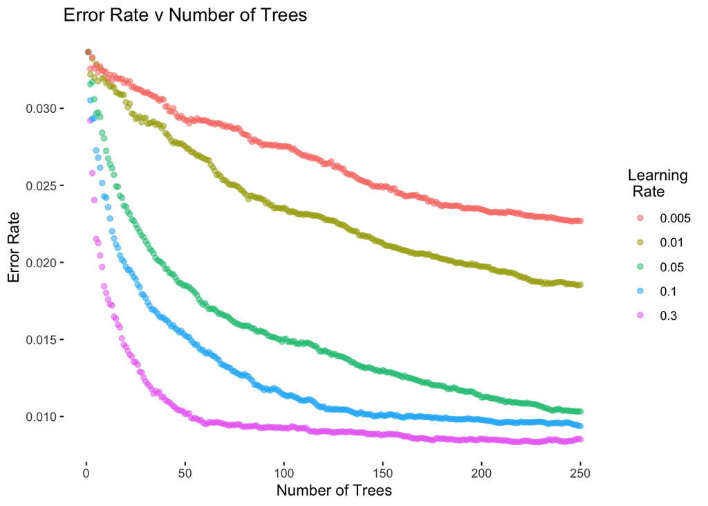

```r
# Extract results for model with eta = 0.3
pd1 <- cbind.data.frame(bst_mod_1$evaluation_log[,c("iter", "test_error_mean")], rep(0.3, nrow(bst_mod_1$evaluation_log)))
names(pd1)[3] <- "eta"
# Extract results for model with eta = 0.1
pd2 <- cbind.data.frame(bst_mod_2$evaluation_log[,c("iter", "test_error_mean")], rep(0.1, nrow(bst_mod_2$evaluation_log)))
names(pd2)[3] <- "eta"
# Extract results for model with eta = 0.05
pd3 <- cbind.data.frame(bst_mod_3$evaluation_log[,c("iter", "test_error_mean")], rep(0.05, nrow(bst_mod_3$evaluation_log)))
names(pd3)[3] <- "eta"
# Extract results for model with eta = 0.01
pd4 <- cbind.data.frame(bst_mod_4$evaluation_log[,c("iter", "test_error_mean")], rep(0.01, nrow(bst_mod_4$evaluation_log)))
names(pd4)[3] <- "eta"
# Extract results for model with eta = 0.005
pd5 <- cbind.data.frame(bst_mod_5$evaluation_log[,c("iter", "test_error_mean")], rep(0.005, nrow(bst_mod_5$evaluation_log)))
names(pd5)[3] <- "eta"
# Join datasets
plot_data <- rbind.data.frame(pd1, pd2, pd3, pd4, pd5)
# Converty ETA to factor
plot_data$eta <- as.factor(plot_data$eta)

# Plot points
g_6 <- ggplot(plot_data, aes(x = iter, y = test_error_mean, color = eta))+
  geom_point(alpha = 0.5) +
  theme_bw() +
  theme(panel.grid.major = element_blank(),
        panel.grid.minor = element_blank(),
        panel.border = element_blank(),
        panel.background = element_blank()) +
  labs(x = "Number of Trees", title = "Error Rate v Number of Trees",
       y = "Error Rate", color = "Learning \n Rate")
g_6
```

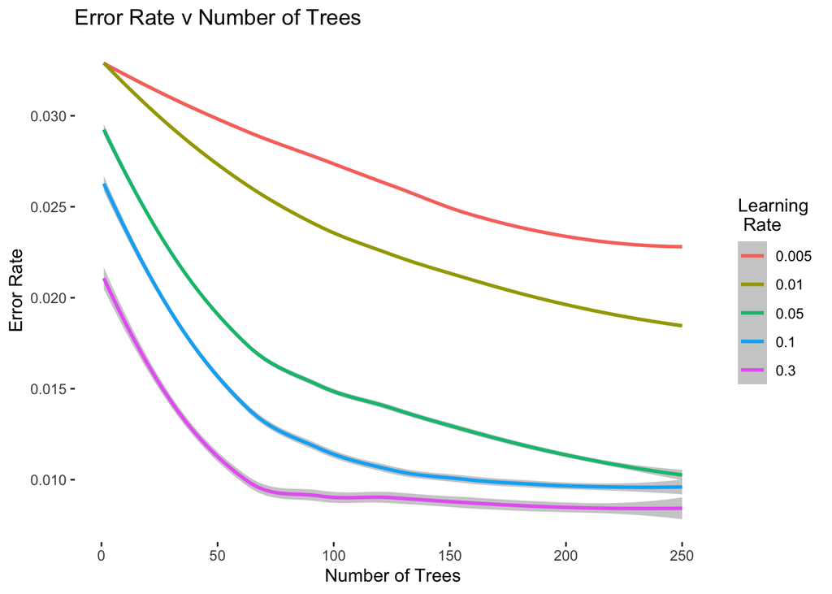

```r
# Plot lines
g_7 <- ggplot(plot_data, aes(x = iter, y = test_error_mean, color = eta))+
  geom_smooth(alpha = 0.5) +
  theme_bw() +
  theme(panel.grid.major = element_blank(),
        panel.grid.minor = element_blank(),
        panel.border = element_blank(),
        panel.background = element_blank()) +
  labs(x = "Number of Trees", title = "Error Rate v Number of Trees",
       y = "Error Rate", color = "Learning \n Rate")
g_7
```

```r
#Select Best Model
bst_final <- xgboost(data = dtrain,
              eta = 0.3,
              nrounds = 75,
              early_stopping_rounds = 25,
              verbose = 1,
              nthread = 1,
              print_every_n = 20,
              objective = "binary:logistic",
              eval_metric = "auc",
              eval_metric = "error")
```

```
## Multiple eval metrics are present. Will use train_error for early stopping.
## Will train until train_error hasn't improved in 25 rounds.
##
```

```r
boost_preds <- predict(bst_final, dtest)
pred_dat <- cbind.data.frame(boost_preds , test_db$label)
boost_pred_class <- rep("nonTOR", length(boost_preds))
boost_pred_class[boost_preds >= 0.5] <- "TOR"
```

- Extract and plot the variable importance for XGBoost (1 mark)

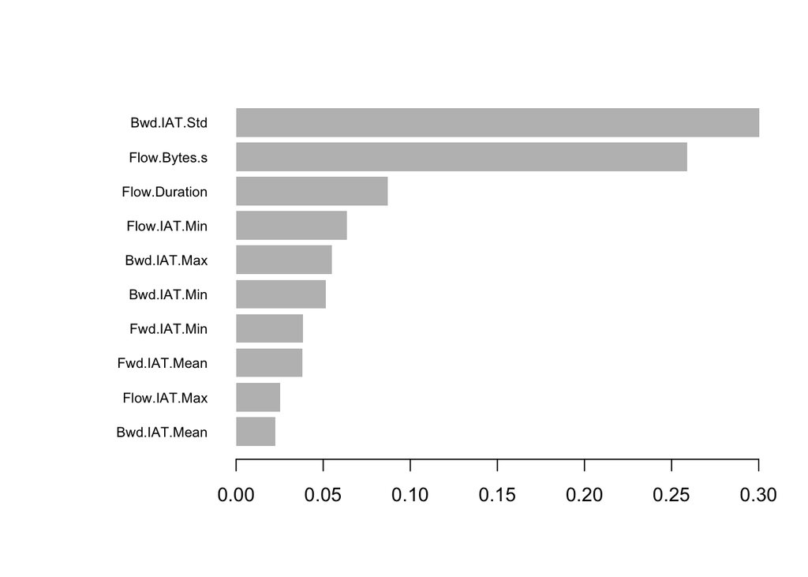

```r
# Extract importance
imp_mat <- xgb.importance(model = bst_final)

# Plot importance (top 10 variables)
xgb.plot.importance(imp_mat, top_n = 10)
```

- Which features were most important for the XGBoost model? (1 mark)

The most important features for the XGBoost model are Bwd.iAT.Std, Flow.Bytes.s and Flow.Duration.

- Compare the three models (Last random forest from pre-assignment, bagging, XGBoost) using an ROC plot. (2 marks)

```r
rf_preds_tor <- rf_preds[, "TOR"]
bag_preds_tor <- bag_preds[, "TOR"]

roc1 = roc(test_db$label, rf_preds_tor)
roc2 = roc(test_db$label, bag_preds_tor)
roc3 = roc(test_db$label, boost_preds)
```

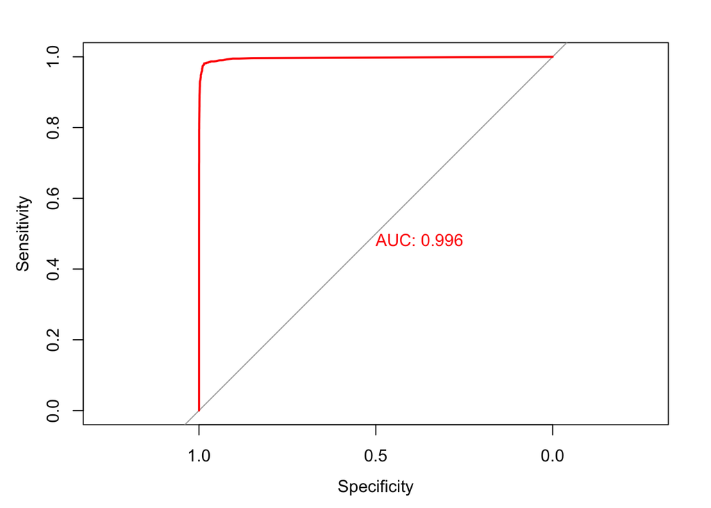

```r
plot.roc(roc1, print.auc = TRUE, col = "red", print.auc.col = "red")
```

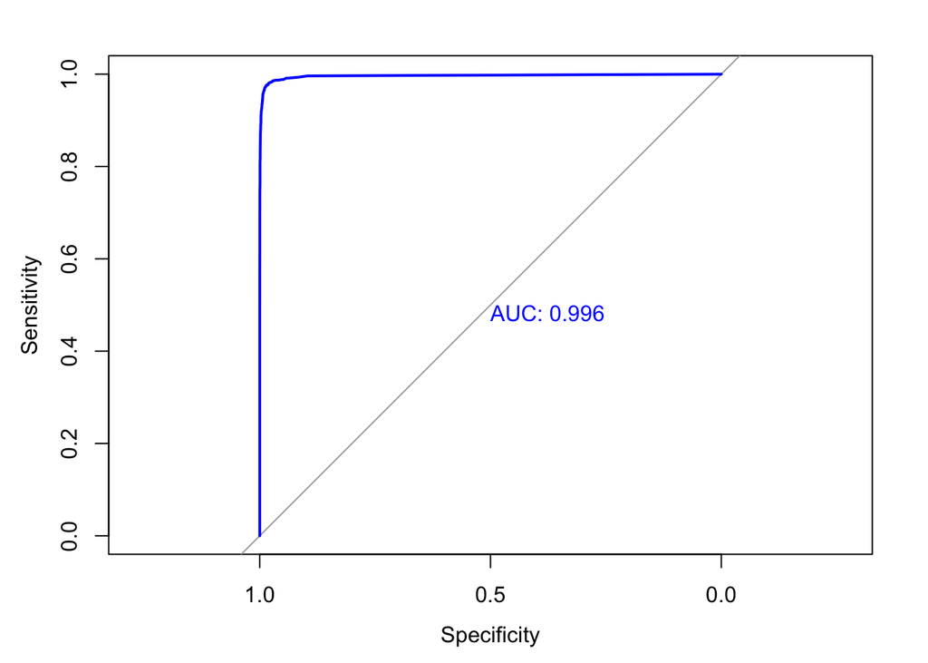

```r
plot.roc(roc2, print.auc = TRUE, col = "blue", print.auc.col = "blue")
```

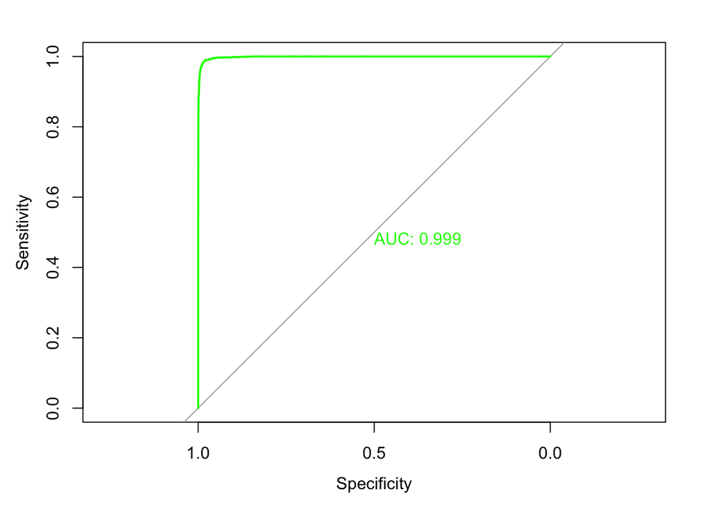

```r
plot.roc(roc3, print.auc = TRUE, col ="green", print.auc.col = "green")
```

```r
summary(as.factor(train_db$label))
```

```
## nonTOR    TOR
##  47828   6436
```

- Which of the three models (random forest, bagging, XGBoost) gave the best results? (1 mark)

Judging from the AUC between the three models, XGBoost gave the best results.

- Can you beat a sensitivity score of 0.96 while keeping overall accuracy above 0.98 and the cut-off set as 0.5? (4 marks - Partial Credit for Attempt)

```r
zero_weight <- 47828/6436
#Select Best Model
bst_final_mod <- xgboost(data = dtrain,
              eta = 0.3,
              nrounds = 75,
              early_stopping_rounds = 25,
              verbose = 1,
              nthread = 1,
              print_every_n = 20,
              scale_pos_weight = zero_weight,
              objective = "binary:logistic",
              eval_metric = "auc",
              eval_metric = "error")
```

```
## Multiple eval metrics are present. Will use train_error for early stopping.
## Will train until train_error hasn't improved in 25 rounds.
##
```

```r
boost_preds_mod <- predict(bst_final_mod, dtest)
pred_dat <- cbind.data.frame(boost_preds_mod , test_db$label)# Convert predictions to classes, using optimal cut-off
boost_pred_class_mod <- rep("nonTOR", length(boost_preds_mod))
boost_pred_class_mod[boost_preds_mod >= 0.5] <- "TOR"

t <- table(boost_pred_class_mod, test_db$label) # Create table
confusionMatrix(t, positive = "TOR")
```

```
## Confusion Matrix and Statistics
##
##
## boost_pred_class_mod nonTOR   TOR
##               nonTOR  11829    34
##               TOR       127  1574
##
##                Accuracy : 0.9881
##                  95% CI : (0.9862, 0.9899)
##     No Information Rate : 0.8815
##     P-Value [Acc > NIR] : < 2.2e-16
##
##                   Kappa : 0.9446
##
##  Mcnemar's Test P-Value : 4.149e-13
##
##             Sensitivity : 0.9789
##             Specificity : 0.9894
##          Pos Pred Value : 0.9253
##          Neg Pred Value : 0.9971
##              Prevalence : 0.1185
##          Detection Rate : 0.1160
##    Detection Prevalence : 0.1254
##       Balanced Accuracy : 0.9841
##
##        'Positive' Class : TOR
##
```

3 marks for analysis decisions, modeling decisions and code readability/usability.